# Análise CBC — Rodada 2 (PIBIC / LMECC)

## 13. Bloco E — Subtipo (3 categorias) × tudo

Substitui as análises de puro/misto da rodada 1.

```
=== [E1] Subtipo × Região anatômica ===  (n = 419)
Frequências:
 regiao_grupo  Cervical  Couro cabeludo  Face — frontal  Face — malar  \
subtipo_3cat
Misto                6               2              17            31
Alto risco           2               3               5            16

regiao_grupo  Face — nariz  Face — outros  Face — perioral/outros  \
subtipo_3cat
Misto                   79              3                      22
Alto risco              43              0                      10

regiao_grupo  Face — pálpebra/periocular  Face — têmpora  Membro inferior  \
subtipo_3cat
Misto                                 16              15                0
Alto risco                            11               5                5

regiao_grupo  Membro superior  Outros  Pavilhão/peri-auricular  Tronco/dorso
subtipo_3cat
Misto                      25       0                       28            28
Alto risco                 13       1                       20            13

% por linha:
 regiao_grupo  Cervical  Couro cabeludo  Face — frontal  Face — malar  \
subtipo_3cat
Misto              2.2             0.7             6.2          11.4
Alto risco         1.4             2.0             3.4          10.9

regiao_grupo  Face — nariz  Face — outros  Face — perioral/outros  \
subtipo_3cat
Misto                 29.0            1.1                     8.1
Alto risco            29.3            0.0                     6.8

regiao_grupo  Face — pálpebra/periocular  Face — têmpora  Membro inferior  \
subtipo_3cat
Misto                                5.9             5.5              0.0
Alto risco                           7.5             3.4              3.4

regiao_grupo  Membro superior  Outros  Pavilhão/peri-auricular  Tronco/dorso
subtipo_3cat
Misto                     9.2     0.0                     10.3          10.3
Alto risco                8.8     0.7                     13.6           8.8

Qui²=18.552, gl=13, p=0.1377 | V Cramer=0.210
⚠ menor esperado=0.35 — interpretar com cautela
```

```
[figura] E1_subtipo_x_regiao.png
```

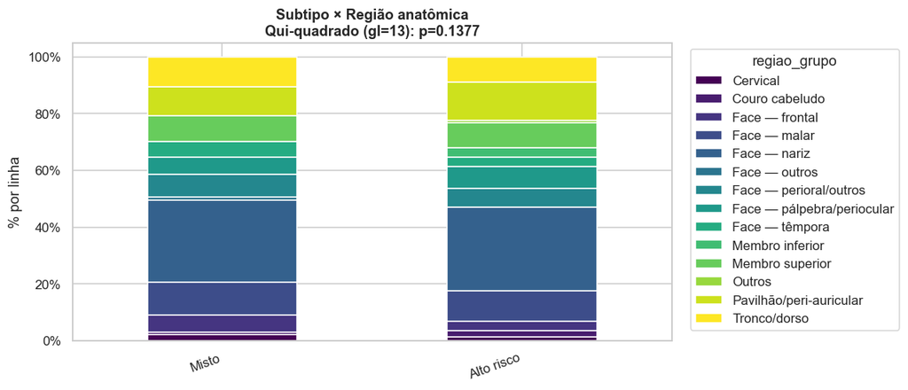

```
Significativo (α=0,05)? NÃO
```

```python
analisa("E","E1","subtipo_3cat","regiao_grupo",
        "Subtipo × Região anatômica",
        "E1_subtipo_x_regiao.png", ordem_lin=ORDEM_SUB)
```

```
=== [E2] Subtipo × Invasão perineural ===  (n = 415)
Frequências:
 inv_perineural  Não  Sim
subtipo_3cat
Misto           254   16
Alto risco      141    4

% por linha:
 inv_perineural   Não  Sim
subtipo_3cat
Misto           94.1  5.9
Alto risco      97.2  2.8

Qui²=1.430, gl=1, p=0.2317 | Fisher p=0.2283 | V Cramer=0.071
```

```
[figura] E2_subtipo_x_perineural.png
```

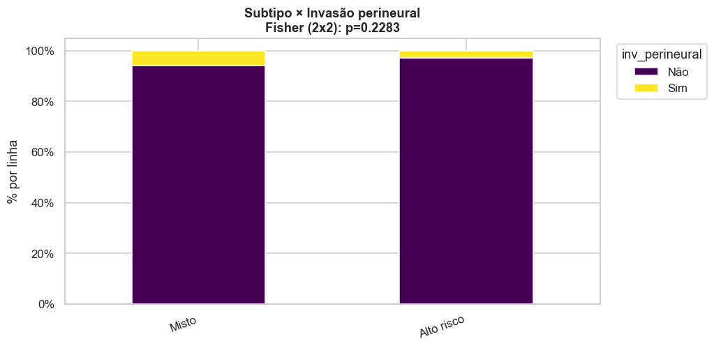

```
Significativo (α=0,05)? NÃO
```

```python
analisa("E","E2","subtipo_3cat","inv_perineural",
        "Subtipo × Invasão perineural",
        "E2_subtipo_x_perineural.png", ordem_lin=ORDEM_SUB, ordem_col=["Não","Sim"])
```

```
=== [E3] Subtipo × Invasão linfovascular ===  (n = 200)
Frequências:
 inv_linfovascular  Não
subtipo_3cat
Misto              137
Alto risco          63

% por linha:
 inv_linfovascular    Não
subtipo_3cat
Misto              100.0
Alto risco         100.0

Qui²=0.000, gl=0, p=1.0000 | V Cramer=nan
```

```
[figura] E3_subtipo_x_linfovascular.png
```

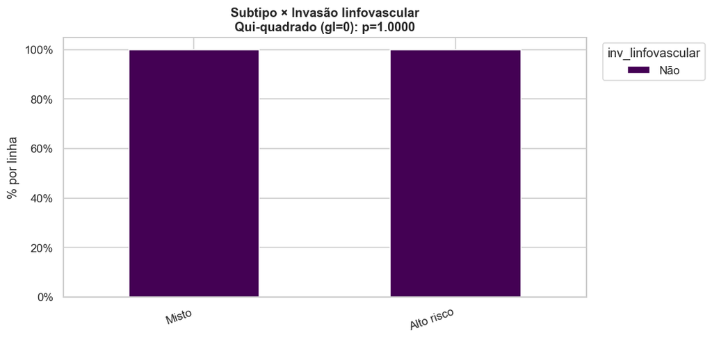

```
Significativo (α=0,05)? NÃO
```

```python
analisa("E","E3","subtipo_3cat","inv_linfovascular",
        "Subtipo × Invasão linfovascular",
        "E3_subtipo_x_linfovascular.png", ordem_lin=ORDEM_SUB)
```

```
=== [E4] Subtipo × Grau de infiltração ===  (n = 389)
Frequências:
 grau_infiltracao  1. Derme  2. Derme reticular  3. Hipoderme/subcutâneo  \
subtipo_3cat
Misto                   15                 183                       44
Alto risco              39                  78                       16

grau_infiltracao  4. Estruturas profundas
subtipo_3cat
Misto                                  13
Alto risco                              1

% por linha:
 grau_infiltracao  1. Derme  2. Derme reticular  3. Hipoderme/subcutâneo  \
subtipo_3cat
Misto                  5.9                71.8                     17.3
Alto risco            29.1                58.2                     11.9

grau_infiltracao  4. Estruturas profundas
subtipo_3cat
Misto                                 5.1
Alto risco                            0.7

Qui²=42.760, gl=3, p=0.0000 | V Cramer=0.332
⚠ menor esperado=4.82 — interpretar com cautela
```

```
[figura] E4_subtipo_x_grau.png
```

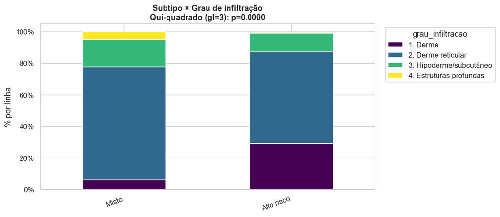

```
Significativo (α=0,05)? SIM
```

```python
analisa("E","E4","subtipo_3cat","grau_infiltracao",
        "Subtipo × Grau de infiltração",
        "E4_subtipo_x_grau.png", ordem_lin=ORDEM_SUB, ordem_col=ORDEM_GRAU)
```

```
=== [E5] Subtipo × Margens comprometidas ===  (n = 416)
Frequências:
 margem_comprometida  Livre  Comprometida
subtipo_3cat
Misto                  238            34
Alto risco             125            19

% por linha:
 margem_comprometida  Livre  Comprometida
subtipo_3cat
Misto                 87.5          12.5
Alto risco            86.8          13.2

Qui²=0.002, gl=1, p=0.9621 | Fisher p=0.8776 | V Cramer=0.010
```

```
[figura] E5_subtipo_x_margens.png
```

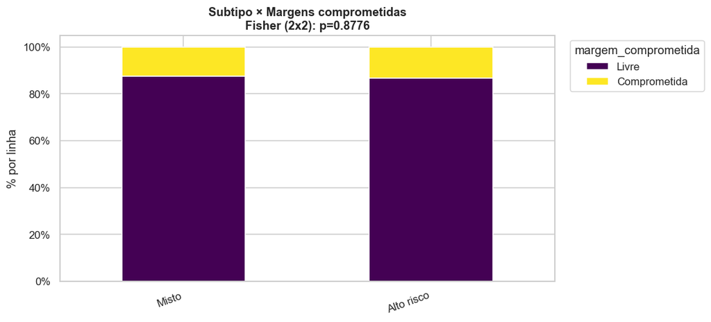

```
Significativo (α=0,05)? NÃO
```

```python
analisa("E","E5","subtipo_3cat","margem_comprometida",
        "Subtipo × Margens comprometidas",
        "E5_subtipo_x_margens.png", ordem_lin=ORDEM_SUB, ordem_col=["Livre","Comprometida"])
```

```
=== [E6] Subtipo × Tamanho da lesão ===  (n = 418)
                n  média  desvio  mediana   q1   q3
subtipo_3cat
Misto         272   1.62    1.19      1.3  0.9  2.0
Alto risco    146   1.43    1.18      1.0  0.7  1.5

Mann-Whitney: U=16835.5, p=0.0101 | r=0.152
```

```
[figura] E6_subtipo_x_tamanho.png
```

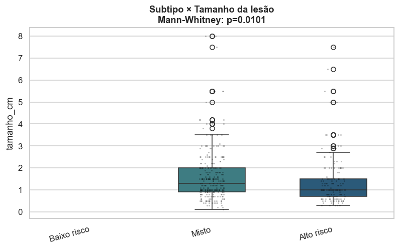

```
Significativo (α=0,05)? SIM
```

```python
analisa("E","E6","subtipo_3cat","tamanho_cm",
        "Subtipo × Tamanho da lesão",
        "E6_subtipo_x_tamanho.png", ordem_lin=ORDEM_SUB, continua=True)
```

```
=== [E7] Subtipo × Ulceração ===  (n = 415)
Frequências:
 ulceracao     Não  Sim
subtipo_3cat
Misto          98  173
Alto risco     49   95

% por linha:
 ulceracao      Não   Sim
subtipo_3cat
Misto         36.2  63.8
Alto risco    34.0  66.0

Qui²=0.106, gl=1, p=0.7452 | Fisher p=0.7465 | V Cramer=0.021
```

```
[figura] E7_subtipo_x_ulceracao.png
```

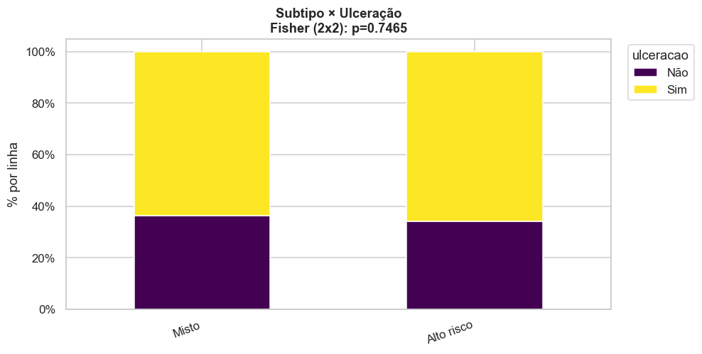

```
Significativo (α=0,05)? NÃO
```

```python
analisa("E","E7","subtipo_3cat","ulceracao",
        "Subtipo × Ulceração",
        "E7_subtipo_x_ulceracao.png", ordem_lin=ORDEM_SUB, ordem_col=["Não","Sim"])
```

## 14. Tabela-mestre de p-valores

```python
master = pd.DataFrame(RESULTADOS)
# ordem dos blocos
master["bloco"] = pd.Categorical(master["bloco"], categories=["A","B","C","D","E"], ordered=True)
master = master.sort_values(["bloco","codigo"]).reset_index(drop=True)
master.to_excel("resumo_pvalores.xlsx", index=False)
print("[exportado] resumo_pvalores.xlsx\n")
sig = master[master["significativo"]=="SIM"]
print(f"Cruzamentos com p < 0,05: {len(sig)} de {len(master)}\n")
print(sig[["bloco","codigo","cruzamento","n","teste","p_valor","efeito"]].to_string(index=False))
```

```
[exportado] resumo_pvalores.xlsx

Cruzamentos com p < 0,05: 9 de 37

bloco codigo                                 cruzamento   n                teste  p_valor  efeito
    B     B5            Faixa etária × Tamanho da lesão 416         Mann-Whitney   0.0000   0.539
    C     C2                Exposição solar × Ulceração 319         Fisher (2x2)   0.0143   0.140
    C     C6 Exposição solar × Tamanho da lesão (média) 322         Mann-Whitney   0.0034   0.207
    D     D3             Região × Margens comprometidas 416 Qui-quadrado (gl=13)   0.0143   0.253
    D     D6                         Região × Ulceração 415 Qui-quadrado (gl=13)   0.0030   0.275
    D     D7               Região × Grau de infiltração 389 Qui-quadrado (gl=39)   0.0000   0.294
    D     D8                  Região × Tamanho da lesão 418       Kruskal-Wallis   0.0000   0.186
    E     E4              Subtipo × Grau de infiltração 389  Qui-quadrado (gl=3)   0.0000   0.332
    E     E6                 Subtipo × Tamanho da lesão 418         Mann-Whitney   0.0101   0.152
```

```python
master.style.apply(lambda r: ["background-color: #d4edda" if r["significativo"]=="SIM" else "" for _ in r], axis=1)
```

|  | bloco | codigo | cruzamento | n | teste | estatistica | p_valor | efeito | significativo |
| --- | --- | --- | --- | --- | --- | --- | --- | --- | --- |
| 0 | A | A1 | Homens — Estado civil × Grau de infiltração | 236 | Qui-quadrado (gl=3) | 6.609000 | 0.085500 | 0.167000 | não |
| 1 | A | A2 | Homens — Estado civil × Tamanho da lesão (cm) | 248 | Mann-Whitney | 8144.000000 | 0.109900 | -0.121000 | não |
| 2 | A | A3 | Homens — Estado civil × Ulceração | 246 | Fisher (2x2) | 0.039000 | 0.775600 | 0.022000 | não |
| 3 | A | A4 | Homens — Estado civil × Margens comprometidas | 245 | Fisher (2x2) | 1.173000 | 0.244200 | 0.082000 | não |
| 4 | A | A5 | Mulheres — Estado civil × Grau de infiltração | 147 | Qui-quadrado (gl=3) | 4.705000 | 0.194700 | 0.179000 | não |
| 5 | A | A6 | Mulheres — Estado civil × Tamanho da lesão (cm) | 163 | Mann-Whitney | 3126.500000 | 0.524000 | 0.058000 | não |
| 6 | A | A7 | Mulheres — Estado civil × Ulceração | 162 | Fisher (2x2) | 2.906000 | 0.081800 | 0.146000 | não |
| 7 | A | A8 | Mulheres — Estado civil × Margens comprometidas | 164 | Fisher (2x2) | 0.000000 | 1.000000 | 0.004000 | não |
| 8 | B | B1 | Faixa etária × Margens comprometidas | 414 | Fisher (2x2) | 0.860000 | 0.336400 | 0.061000 | não |
| 9 | B | B2 | Faixa etária × Invasão perineural | 413 | Fisher (2x2) | 1.920000 | 0.092300 | 0.093000 | não |
| 10 | B | B3 | Faixa etária × Invasão linfovascular | 198 | Qui-quadrado (gl=0) | 0.000000 | 1.000000 | nan | não |
| 11 | B | B4 | Faixa etária × Ulceração | 413 | Fisher (2x2) | 0.343000 | 0.497100 | 0.040000 | não |
| 12 | B | B5 | Faixa etária × Tamanho da lesão | 416 | Mann-Whitney | 2084.500000 | 0.000000 | 0.539000 | SIM |
| 13 | B | B6 | Faixa etária × Grau de infiltração | 387 | Qui-quadrado (gl=3) | 3.831000 | 0.280300 | 0.099000 | não |
| 14 | B | B7 | Faixa etária × Subtipo (3 cat) | 417 | Fisher (2x2) | 0.458000 | 0.374900 | 0.044000 | não |
| 15 | C | C1 | Exposição solar × Subtipo (3 cat) | 322 | Fisher (2x2) | 0.213000 | 0.613400 | 0.033000 | não |
| 16 | C | C2 | Exposição solar × Ulceração | 319 | Fisher (2x2) | 5.588000 | 0.014300 | 0.140000 | SIM |
| 17 | C | C3 | Exposição solar × Invasão perineural | 318 | Fisher (2x2) | 0.188000 | 0.574300 | 0.040000 | não |
| 18 | C | C4 | Exposição solar × Invasão linfovascular | 156 | Qui-quadrado (gl=0) | 0.000000 | 1.000000 | nan | não |
| 19 | C | C5 | Exposição solar × Margens comprometidas | 319 | Fisher (2x2) | 2.687000 | 0.096100 | 0.102000 | não |
| 20 | C | C6 | Exposição solar × Tamanho da lesão (média) | 322 | Mann-Whitney | 8499.500000 | 0.003400 | 0.207000 | SIM |
| 21 | C | C7 | Exposição solar × Grau de infiltração | 297 | Qui-quadrado (gl=3) | 7.166000 | 0.066800 | 0.155000 | não |
| 22 | D | D1 | Região × Exposição solar | 322 | Qui-quadrado (gl=12) | 17.195000 | 0.142400 | 0.231000 | não |
| 23 | D | D2 | Região × Subtipo (3 cat) | 419 | Qui-quadrado (gl=13) | 18.552000 | 0.137700 | 0.210000 | não |
| 24 | D | D3 | Região × Margens comprometidas | 416 | Qui-quadrado (gl=13) | 26.548000 | 0.014300 | 0.253000 | SIM |
| 25 | D | D4 | Região × Invasão perineural | 415 | Qui-quadrado (gl=13) | 17.571000 | 0.174500 | 0.206000 | não |
| 26 | D | D5 | Região × Invasão linfovascular | 200 | Qui-quadrado (gl=0) | 0.000000 | 1.000000 | nan | não |
| 27 | D | D6 | Região × Ulceração | 415 | Qui-quadrado (gl=13) | 31.377000 | 0.003000 | 0.275000 | SIM |
| 28 | D | D7 | Região × Grau de infiltração | 389 | Qui-quadrado (gl=39) | 101.044000 | 0.000000 | 0.294000 | SIM |
| 29 | D | D8 | Região × Tamanho da lesão | 418 | Kruskal-Wallis | 77.458000 | 0.000000 | 0.186000 | SIM |
| 30 | E | E1 | Subtipo × Região anatômica | 419 | Qui-quadrado (gl=13) | 18.552000 | 0.137700 | 0.210000 | não |
| 31 | E | E2 | Subtipo × Invasão perineural | 415 | Fisher (2x2) | 1.430000 | 0.228300 | 0.071000 | não |
| 32 | E | E3 | Subtipo × Invasão linfovascular | 200 | Qui-quadrado (gl=0) | 0.000000 | 1.000000 | nan | não |
| 33 | E | E4 | Subtipo × Grau de infiltração | 389 | Qui-quadrado (gl=3) | 42.760000 | 0.000000 | 0.332000 | SIM |
| 34 | E | E5 | Subtipo × Margens comprometidas | 416 | Fisher (2x2) | 0.002000 | 0.877600 | 0.010000 | não |
| 35 | E | E6 | Subtipo × Tamanho da lesão | 418 | Mann-Whitney | 16835.500000 | 0.010100 | 0.152000 | SIM |
| 36 | E | E7 | Subtipo × Ulceração | 415 | Fisher (2x2) | 0.106000 | 0.746500 | 0.021000 | não |

## 15. Conclusões e limitações

### Síntese dos achados (37 cruzamentos rodados, 9 significativos)

**Observação importante sobre o subtipo:** ao aplicar a classificação clínica padrão (WHO/NCCN), **nenhuma lesão da amostra ficou em "Baixo risco" puro** — todas as 419 têm pelo menos um componente agressivo. O grupo "3 categorias" funciona na prática como **Misto (272)** vs **Alto risco puro (147)**. Isso é coerente com o fato de a amostra vir de um serviço de patologia (provavelmente já filtra casos clinicamente relevantes).

#### Bloco B — Faixa etária (≤ 40 vs > 40)

**1 cruzamento significativo** (de 7):

- **B5 — Tamanho da lesão**: pacientes ≤ 40 têm tumores **MAIORES** (mediana 2,3 cm; média 2,75) vs. >40 (mediana 1,2 cm; média 1,49) — **p<0,001; r=0,54 (efeito grande)**. Sentido contrário ao esperado de "tumor menor no jovem". Possíveis explicações: diagnóstico tardio em jovens (não esperam câncer nessa faixa) ou comportamento biológico realmente mais expansivo.
- Demais marcadores de agressividade (margens, perineural, ulceração, grau, subtipo) **não diferem por faixa etária**.

#### Bloco C — Exposição solar ocupacional

**2 cruzamentos significativos** (de 7):

- **C2 — Ulceração**: lesões em expostos ao sol ulceram em **69,5%** vs. 54,8% em não expostos (Fisher p=0,014; V=0,14).
- **C6 — Tamanho**: lesões em expostos são **maiores** (mediana 1,2 vs 1,0 cm; média 1,55 vs 1,15; Mann-Whitney p=0,003; r=0,21).

#### Bloco D — Região anatômica × tudo

**4 cruzamentos significativos** (de 8) — **o sítio anatômico importa muito**:

- **D3 — Margens comprometidas** (Qui² p=0,014; V=0,25)
- **D6 — Ulceração** (p=0,003; V=0,28)
- **D7 — Grau de infiltração** (p<0,001; V=0,29)
- **D8 — Tamanho** (Kruskal-Wallis p<0,001; η²=0,19): regiões com lesões maiores → **membro superior (mediana 2,25 cm)** e **tronco/dorso (2,0 cm)**; menores → face — nariz, perioral e pálpebra (~1,0 cm).

#### Bloco E — Subtipo (Misto vs Alto risco puro)

**2 cruzamentos significativos** (de 7):

- **E4 — Grau de infiltração** (Qui² p<0,001; V=0,33 — **efeito moderado**): lesões **Mistas** infiltram mais profundamente (71,8% derme reticular + 17,3% hipoderme + 5,1% estruturas profundas) do que Alto risco puro (58,2% reticular; só 0,7% estruturas profundas). Provavelmente porque o componente nodular/sólido associado ao agressivo dá mais massa tumoral.
- **E6 — Tamanho** (Mann-Whitney p=0,010; r=0,15): Mistos ligeiramente maiores (média 1,62 vs 1,43 cm).